# Act_Report

## Introduction

###### In thes reoprt i will give you sum analysis informations for the WeRateDogs, It’s a Twitter public account that has over 6 million followers and recived international media coverage, and its fore the peoples how rates dogs withe a diftent type of them fore exsample doggo, floofer, pupper and puppo.

###### This account allows people to send photos of their dog, then tweets selected photos rating and a humorous comment. Dogs are rated on a scale of one to ten, but are invariably given ratings in excess of the maximum, such as "13/10". Popular posts are re-posted on Instagram and Facebook. Besides, the account's language has spawned an Internet language about "doggos" and "puppers".

###### And here we can notice the following informations about it:

###### * Tweet Retweet Vs Favorites

###### * The Repartition Of The Dog Stages

###### * The Most Popular Dog Name

### Tweet Retweet Vs Favorites

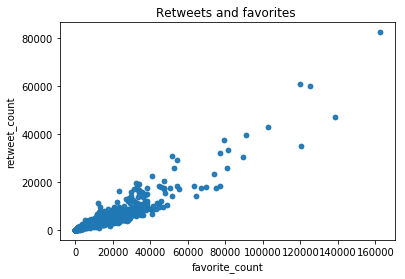

- We can say that the correlation shows us that retweet is high correlated with favorites.

### The Repartition Of The Dog Stages

[figure not shown]